# proj-ass

## Assignment 1 for Repeatable Research

This is an R Markdown document.

1. Load the data.

```r
##Sys.setlocale("LC_ALL","Chinese")
setwd("C:/迅雷下载/Data Science Cert/Course 5 - Reproducible research/wk2")

ACT <- read.csv("./repdata_data_activity/activity.csv")
```

2. Process/transform the data (if necessary) into a format suitable for your analysis.

### What is mean total number of steps taken per day?

For this part of the assignment, you can ignore the missing values in the dataset. 1. Calculate the total number of steps taken per day

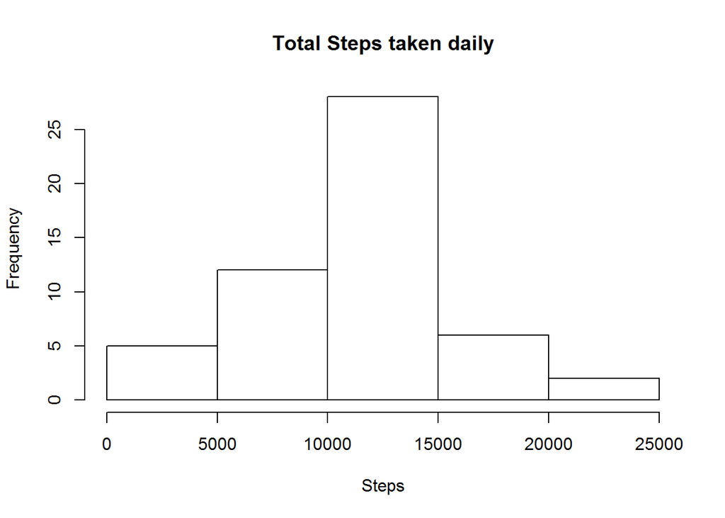

```r
stepbydate<-aggregate(steps ~ date, ACT, sum)
#Make a histogram of the total number of steps taken each day
hist(stepbydate$steps,main="Total Steps taken daily",xlab="Steps")
```

```r
mean(stepbydate$steps)
```

```
## [1] 10766.19
```

```r
median(stepbydate$steps)
```

```
## [1] 10765
```

### What is the average daily activity pattern?

1.Make a time series plot (i.e.type = “l”) of the 5-minute interval (x-axis) and the average number of steps taken, averaged across all days (y-axis)

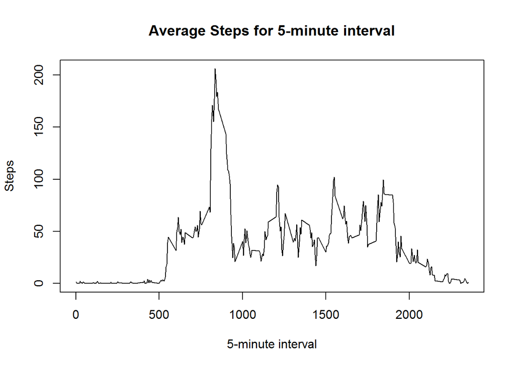

```r
MeanStep5min=aggregate(steps ~ interval, ACT, mean,na.rm=TRUE)

plot(MeanStep5min[1]$interval,MeanStep5min[2]$steps,type = "l",main = "Average Steps for 5-minute interval",xlab = "5-minute interval",ylab = "Steps")
```

Which 5-minute interval, on average across all the days in the dataset, contains the maximum number of steps?

```r
which.max(MeanStep5min$steps)
```

```
## [1] 104
```

### Imputing missing values

1.The total number of missing values in the dataset (i.e. the total number of rows with NAs)

```r
sum(is.na(ACT$steps))
```

```
## [1] 2304
```

2.Devise a strategy for filling in all of the missing values in the dataset.

3.Create a new dataset that is equal to the original dataset but with the missing data filled in.

```r
newACT <- ACT
newACT[is.na(ACT$steps),][1]=mean(ACT$steps,na.rm=T)
```

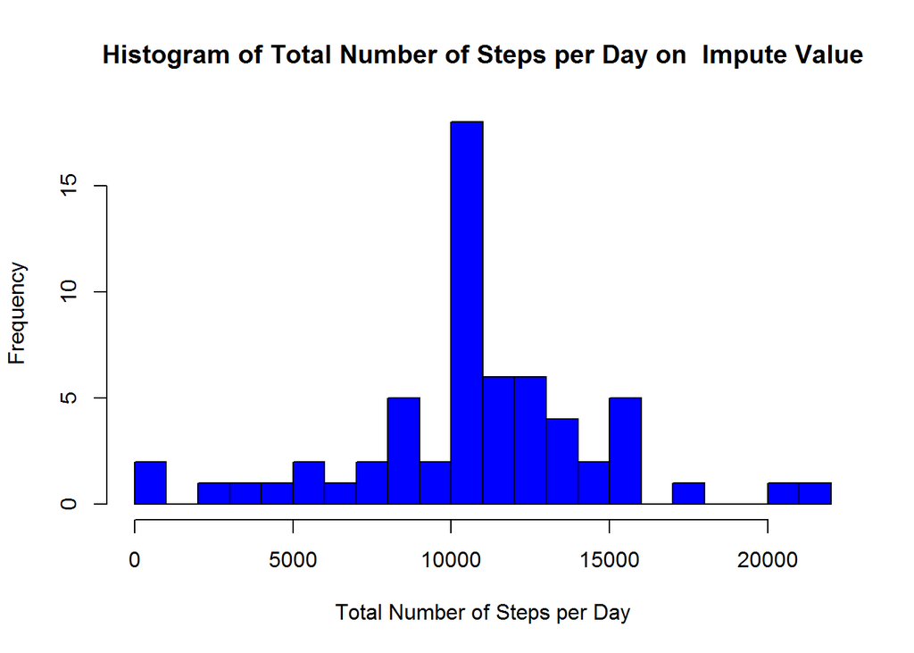

```r
stepDaily<-tapply(newACT$steps,newACT$date,sum)
hist(stepDaily,main = "Histogram of Total Number of Steps per Day on  Impute Value", xlab = "Total Number of Steps per Day", col = "blue",breaks = 30)
```

```r
mean(tapply(ACT$steps,ACT$date,sum),na.rm=T)
```

```
## [1] 10766.19
```

```r
median(tapply(ACT$steps,ACT$date,sum),na.rm=T)
```

```
## [1] 10765
```

### Are there differences in activity patterns between weekdays and weekends?

Use the dataset with the filled-in missing values for this part.

```r
library(lubridate)
newACT$wday<-wday(as.Date(ACT$date))
newACT$wday2<-ifelse(newACT$wday==7|newACT$wday==1,"Weekend","Weekday")

##Sys.setlocale("LC_ALL","English")
##newACT$day<-weekdays(as.Date(newACT$date))
stepsByWeekday<-aggregate(newACT$steps,list(newACT$interval, newACT$wday2),mean)
head(stepsByWeekday)
```

```
##   Group.1 Group.2        x
## 1       0 Weekday 7.006569
## 2       5 Weekday 5.384347
## 3      10 Weekday 5.139902
## 4      15 Weekday 5.162124
## 5      20 Weekday 5.073235
## 6      25 Weekday 6.295458
```

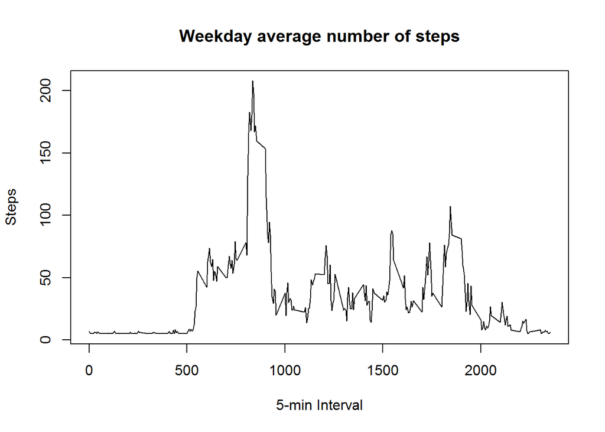

```r
dataWeekend<-stepsByWeekday[stepsByWeekday$Group.2=="Weekend",]
dataWeekday<-stepsByWeekday[stepsByWeekday$Group.2=="Weekday",]
plot(dataWeekday$Group.1,dataWeekday$x,type = "l",main="Weekday average number of steps",ylab = "Steps",xlab = "5-min Interval")
```

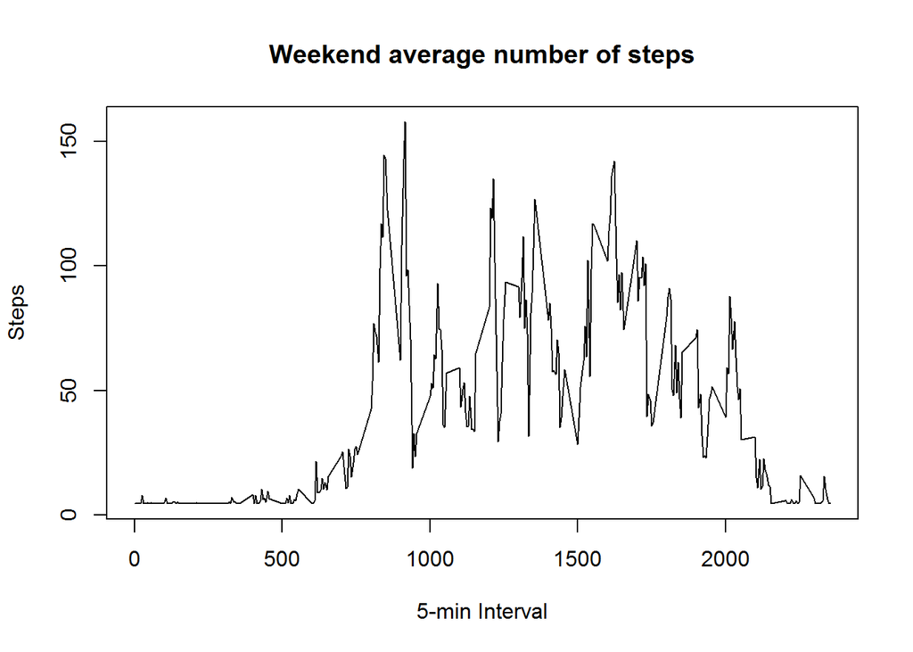

```r
plot(dataWeekend$Group.1,dataWeekend$x,type = "l",main="Weekend average number of steps",ylab = "Steps",xlab = "5-min Interval")
```